# Identify if the domains we have identified tend to bind linear motifs (the domains we have identified are enriched in domains known to bind linear motifs)

Vitalii Kleshchevnikov

17/08/2017

## Setting up how many cores to use for analysis and fold-enrichment vs freqency

```r
# cores to use for multiprocessing: is the number of cores is small -> we are not on a cluster -> use all; if the number of cores is large -> we are on cluster -> use only 15 or 7 or 31 cores (n requested-1)
if(detectCores() <= 4) cores_to_use = detectCores() - 1
if(detectCores() > 4) cores_to_use = 31

# how many permutations?
N_permut = 500000
```

# How many of the domains identified using our approach are in the ELM database (as compared to the population of all domains we tested)?

## Calculate empirical pvalues using count of a domain among interacting partners of viral protein

```r
data = fread("./processed_data_files/viral_human_net_w_domains", sep = "\t", stringsAsFactors = F)
# count function: set up standard parameters
permuteCount = function(data, select_nodes = NULL, also_permuteYZ = F){
    res = permutationPval(interactions2permute = IDs_interactor_viral ~ IDs_interactor_human, # first set of interacting pairs (XY) that are to be permuted
                          associations2test = IDs_interactor_viral ~ IDs_domain_human, # set of interacting pairs to be tested (XZ), YZ interactions are assumed
                          node_attr = list(IDs_interactor_viral ~ IDs_interactor_viral_degree,
                                           IDs_domain_human ~ domain_count,
                                           IDs_interactor_viral + IDs_domain_human ~ domain_frequency_per_IDs_interactor_viral),
                          data = data,
                          statistic = IDs_interactor_viral + IDs_domain_human ~ .N,
                          select_nodes = select_nodes,
                          N = N_permut,
                          cores = cores_to_use, seed = 2, also_permuteYZ = also_permuteYZ)
    return(res)
}
# count: all proteins and domains - # permute IDs_interactor_viral ~ IDs_interactor_human
time = proc.time()
res_count = permuteCount(data, select_nodes = NULL)
proc.time() - time
```

```
##      user    system   elapsed
##    82.117     8.888 80157.130
```

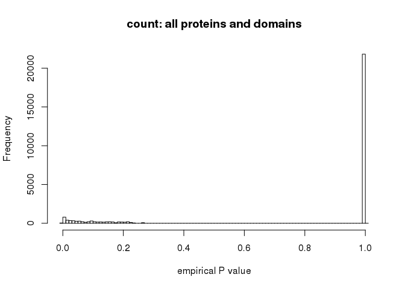

```r
plot(res_count, main = "count: all proteins and domains")
```

```r
# Fisher test: set up standard parameters
permuteFisherTestOdds = function(data, select_nodes = NULL, also_permuteYZ = F, N = N_permut){
    resFISHER = permutationPval(interactions2permute = IDs_interactor_viral ~ IDs_interactor_human, # first set of interacting pairs (XY) that are to be permuted
                                associations2test = IDs_interactor_viral ~ IDs_domain_human, # set of interacting pairs to be tested (XZ), YZ interactions are assumed
                                node_attr = list(IDs_interactor_viral ~ IDs_interactor_viral_degree, # attribute of X
                                                 IDs_domain_human ~ domain_count + N_prot_w_interactors, # attributes of Z
                                                 IDs_interactor_viral + IDs_domain_human ~ domain_count_per_IDs_interactor_viral), # attribute of both X and Z
                                data = data, # data.table containing data
                                statistic = IDs_interactor_viral + IDs_domain_human ~ fisher.test(
                                    matrix(c(domain_count_per_IDs_interactor_viral[1],
                                             IDs_interactor_viral_degree[1] - domain_count_per_IDs_interactor_viral[1],
                                             domain_count[1] - domain_count_per_IDs_interactor_viral[1],
                                             N_prot_w_interactors[1] - domain_count[1] - IDs_interactor_viral_degree[1] + domain_count_per_IDs_interactor_viral[1]),
                                           2,2),
                                    alternative = "greater", conf.int = F)$estimate, # formula to calculate statisic by evaluating right-hand-side expression for each X and Z pair, right-hand-side expression is what is normally put in j in data.table DT[i, j, by], left-hand-side expression contains column names of X and Z which are used in by in data.table
                                select_nodes = select_nodes, # select a subset of the data, only nodes
                                N = N, # number of permutations
                                cores = cores_to_use, seed = 1, also_permuteYZ = also_permuteYZ)
    # permutationPval returns the number of cases when permuted statitic is higher than the observed statistic (right tail of the distribution), in this case we are interested in the reverse - the lower tail, when p-values from permuted distribution that are lower than the observed p-value
    resFISHER$data_with_pval[, p.value := 1 - p.value]
    return(resFISHER)
}

# permute IDs_interactor_viral ~ IDs_interactor_human: odds ratio
resFISHERodds = permuteFisherTestOdds(data, select_nodes = NULL, N = 1)

# Just FisherTest result (no permutation)
justFisherdata = copy(resFISHERodds$data_with_pval)
justFisherdata[, resFISHERodds_p.value := p.value][, p.value := NULL]
justFisherdata[, odds_ratio := observed_statistic][, observed_statistic := NULL]
justFisherdata[, resFISHERodds_YmissingZ_perX := YmissingZ_perX][, YmissingZ_perX := NULL]
justFisherdata[, resFISHERodds_higher_counts := higher_counts][, higher_counts := NULL]
justFisherdata[, resFISHERodds_not_missing := not_missing][, not_missing := NULL]

# Fisher test: set up standard parameters
permuteFisherTestPval = function(data, select_nodes = NULL, also_permuteYZ = F, N = N_permut){
    resFISHER = permutationPval(interactions2permute = IDs_interactor_viral ~ IDs_interactor_human, # first set of interacting pairs (XY) that are to be permuted
                                associations2test = IDs_interactor_viral ~ IDs_domain_human, # set of interacting pairs to be tested (XZ), YZ interactions are assumed
                                node_attr = list(IDs_interactor_viral ~ IDs_interactor_viral_degree, # attribute of X
                                                 IDs_domain_human ~ domain_count + N_prot_w_interactors, # attributes of Z
                                                 IDs_interactor_viral + IDs_domain_human ~ domain_count_per_IDs_interactor_viral), # attribute of both X and Z
                                data = data, # data.table containing data
                                statistic = IDs_interactor_viral + IDs_domain_human ~ fisher.test(
                                    matrix(c(domain_count_per_IDs_interactor_viral[1],
                                             IDs_interactor_viral_degree[1] - domain_count_per_IDs_interactor_viral[1],
                                             domain_count[1] - domain_count_per_IDs_interactor_viral[1],
                                             N_prot_w_interactors[1] - domain_count[1] - IDs_interactor_viral_degree[1] + domain_count_per_IDs_interactor_viral[1]),
                                           2,2),
                                    alternative = "greater", conf.int = F)$p.value, # formula to calculate statisic by evaluating right-hand-side expression for each X and Z pair, right-hand-side expression is what is normally put in j in data.table DT[i, j, by], left-hand-side expression contains column names of X and Z which are used in by in data.table
                                select_nodes = select_nodes, # select a subset of the data, only nodes
                                N = N, # number of permutations
                                cores = cores_to_use, seed = 1, also_permuteYZ = also_permuteYZ)
    # permutationPval returns the number of cases when permuted statitic is higher than the observed statistic (right tail of the distribution), in this case we are interested in the reverse - the lower tail, when p-values from permuted distribution that are lower than the observed p-value
    resFISHER$data_with_pval[, p.value := 1 - p.value]
    return(resFISHER)
}

resJustFISHER = permuteFisherTestPval(justFisherdata, select_nodes = NULL, N = 1)

resJustFISHER$data_with_pval[, p.value := observed_statistic]
resJustFISHER$data_with_pval[, observed_statistic := odds_ratio]

my.p.adjust = function(res, adj_by = "p.value", ...) {
    if(class(res) != "XYZinteration_XZEmpiricalPval") stop("res should be the output of permutationPval()")
    if("fdr_pval" %in% colnames(res$data_with_pval)) stop("p value has already been fdr-corrected")
    columns = adj_by
    adj_by = formula(paste0("~",adj_by))[[2]]
    nodes = c(res$nodes$nodeX, res$nodes$nodeZ)
    columns = c(nodes, columns)
    temp = unique(res$data_with_pval[, c(columns), with = F])
    temp[, fdr_pval := p.adjust(eval(adj_by), ...)]
    res$data_with_pval = res$data_with_pval[temp, on = c(columns)]
    res
}
resJustFISHER = my.p.adjust(resJustFISHER, method = "fdr")
resJustFISHER005 = copy(resJustFISHER)
resJustFISHER005$data_with_pval = resJustFISHER$data_with_pval[fdr_pval < 0.05,]
resJustFISHER01 = copy(resJustFISHER)
resJustFISHER01$data_with_pval = resJustFISHER$data_with_pval[fdr_pval < 0.1,]
resJustFISHER001 = copy(resJustFISHER)
resJustFISHER001$data_with_pval = resJustFISHER$data_with_pval[fdr_pval < 0.01,]
```

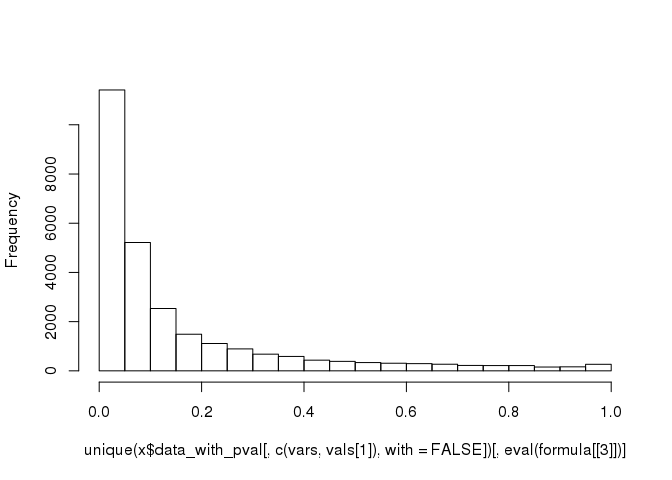

```r
# Fisher test gives the probability of the domain being enriched over the background P(D)
# If we do just the Fisher test we see that the top-scoring domains (overwhelming majority) are those seen at count 1, we need to account for the probability of seeing different counts while looking at viral proteins individually
# Permutations give the probability of seeing specific domain counts P(count)
# P(cound|D) are the frequencies of each count as is while looking at viral proteins individually
# We want to find P(D|count) = (P(count|D) * P(D)) / P(count)
# P.D_count. = P.count_D. * P.D. / P.count.
bayes = function(resJustFISHER, res_count, P.D. = "p.value", P.count. = "p.value", degree = "IDs_interactor_viral_degree", count = "domain_count_per_IDs_interactor_viral"){
    if(identical(c(resJustFISHER$nodes$nodeX, resJustFISHER$nodes$nodeZ),
                 c(res_count$nodes$nodeX, res_count$nodes$nodeZ))) {
        nodes = c(res_count$nodes$nodeX, res_count$nodes$nodeZ)
    } else stop("resJustFISHER and res_count contain data for different nodes")
    count_data = unique(res_count$data_with_pval[, c(nodes, P.count., degree, count,"observed_statistic"), with = F])
    count_data[, domains_per_prot := .N, by = .(eval(formula(paste0("~",res_count$nodes$nodeX))[[2]]))]
    count_data[, P.count_D. := .N / domains_per_prot,
                   by = .(eval(formula("~observed_statistic")[[2]]),
                                          eval(formula(paste0("~",res_count$nodes$nodeX))[[2]]))]
    # count_data[, P.count_D. := eval(formula(paste0("~",count))[[2]]) / eval(formula(paste0("~",degree))[[2]])]
    count_data[, P.count. := p.value]
    count_data[, c("p.value", "observed_statistic", "domains_per_prot") := NULL]

    just_fisher = copy(resJustFISHER)
    just_fisher$data_with_pval = just_fisher$data_with_pval[count_data, on = nodes]
    just_fisher$data_with_pval[, P.D. := eval(formula(paste0("~",P.D.))[[2]])]

    just_fisher$data_with_pval[, P.D. := 1 - P.D.]
    just_fisher$data_with_pval[, P.count_D. := P.count_D.]
    just_fisher$data_with_pval[, P.count. := 1 - P.count.]
    just_fisher$data_with_pval[, P.D_count. := P.count_D. * P.D. / P.count.]

    just_fisher$data_with_pval[, p.value := 1 - P.D_count.]

    just_fisher
}

resBayes = bayes(resJustFISHER, res_count)
plot(resJustFISHER, IDs_interactor_viral + IDs_domain_human ~ fdr_pval)
```

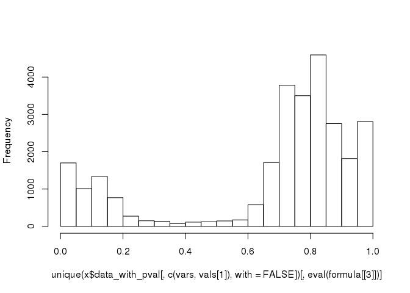

```r
plot(resBayes, IDs_interactor_viral + IDs_domain_human ~ P.count_D.)
```

```r
bayes2 = function(resJustFISHER, res_count, P.D. = "p.value", P.count. = "p.value", degree = "IDs_interactor_viral_degree", count = "domain_count_per_IDs_interactor_viral"){
    if(identical(c(resJustFISHER$nodes$nodeX, resJustFISHER$nodes$nodeZ),
                 c(res_count$nodes$nodeX, res_count$nodes$nodeZ))) {
        nodes = c(res_count$nodes$nodeX, res_count$nodes$nodeZ)
    } else stop("resJustFISHER and res_count contain data for different nodes")
    count_data = unique(res_count$data_with_pval[, c(nodes, P.count., degree, count,"observed_statistic"), with = F])
    count_data[, prots_per_domain := .N, by = .(eval(formula(paste0("~",res_count$nodes$nodeZ))[[2]]))]
    #count_data[, P.count_D. := .N / prots_per_domain,
    #               by = .(eval(formula("~observed_statistic")[[2]]),
    #                                      eval(formula(paste0("~",res_count$nodes$nodeZ))[[2]]))]
    count_data[, P.count_D. := p.value]
    count_data[, P.count. := p.value]
    count_data[, c("p.value", "observed_statistic", "domains_per_prot") := NULL]

    just_fisher = copy(resJustFISHER)
    just_fisher$data_with_pval = just_fisher$data_with_pval[count_data, on = nodes]
    just_fisher$data_with_pval[, P.D. := eval(formula(paste0("~",P.D.))[[2]])]

    just_fisher$data_with_pval[, P.D. := 1 - P.D.]
    just_fisher$data_with_pval[, P.count_D. := P.count_D.]
    just_fisher$data_with_pval[, P.count. := 1 - P.count.]
    just_fisher$data_with_pval[, P.D_count. := P.count_D. * P.D. / P.count.]

    just_fisher$data_with_pval[, p.value := 1 - P.D_count.]

    just_fisher
}

resBayes2 = bayes2(resJustFISHER, res_count)
```

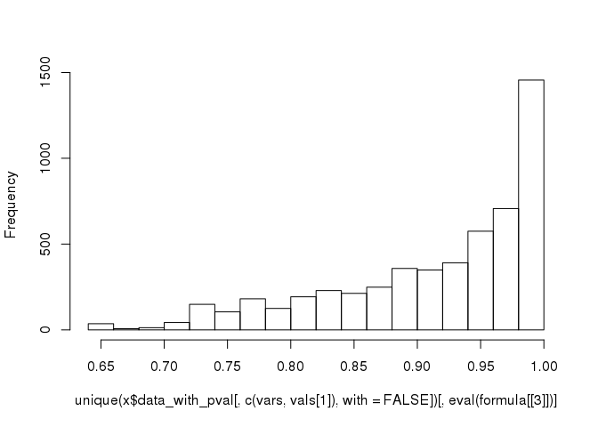

```r
plot(resBayes2, IDs_interactor_viral + IDs_domain_human ~ p.value)
```

## Viral protein degree and the background domain count of top-scoring proteins

```r
# count
PermutResult2D(res = res_count, N = 250) +
    ggtitle("2D-bin plots of 250 top-scoring viral protein - human domain pairs, \n statistic: count of a domain among interacting partners of a viral protein")

# Fisher test p-value
PermutResult2D(res = resJustFISHER, N = 250) +
    ggtitle("2D-bin plots of 250 top-scoring viral protein - human domain pairs, \n statistic: Fisher test p-value")
```

[output not shown]

## Map domains known to interact with linear motifs from ELM to the domains we found

```r
if(!file.exists("./data_files/interactiondomains.tsv")) downloader::download("http://elm.eu.org/interactiondomains.tsv","./data_files/interactiondomains.tsv")
interactiondomains = fread("./data_files/interactiondomains.tsv")
interactiondomains[, pfam_id := `Interaction Domain Id`]

domains_known = interactiondomains[, unique(pfam_id)]

InterProScan_domains = readInterProGFF3("../viral_project/processed_data_files/all_human_viral_protein_domains.gff3.gz")
# get InterProID to member database ID mapping
InterPro2memberDB = getInterPro2memberDB(InterProScan_domains)
InterPro2memberDB = InterPro2memberDB[complete.cases(InterPro2memberDB)]
domains_known_mapped = unique(InterPro2memberDB[memberDBID %in% domains_known | InterProID %in% domains_known, InterProID])
domains_not_mapped = unique(domains_known[!(domains_known %in% InterPro2memberDB$memberDBID | domains_known %in% InterPro2memberDB$InterProID)])
```

I did Fisher test to evaluate if the domains that we find are enriched in domains known to interact with linear motifs (from ELM). I have picked some number of viral protein - human domain associations from the top (by p-value). Then I counted how many known domains we have found and did Fisher test. I decided to compare two statistic choices (frequency of a domain among interacting partners of a viral protein or Fisher test p-value) on how many of the known domains we tend to find. Finally, I was choosing different cutoffs (different number of top p-value pairs).

```r
testEnrichment = function(N, res, rank_by = "p.value", domains_known_mapped, random = F, name = "", decreasing = F){
    if(random) {
        res$data_pval = unique(res$data_with_pval[,c("IDs_interactor_viral", "IDs_domain_human", rank_by, "domain_type", "domain_count", "IDs_interactor_viral_degree"), with = F])
        domains_found = res$data_pval[sample(1:nrow(res$data_with_pval), N), unique(IDs_domain_human)]
    } else {
        res$data_pval = unique(res$data_with_pval[,c("IDs_interactor_viral", "IDs_domain_human", rank_by, "domain_type", "domain_count", "IDs_interactor_viral_degree"), with = F])
        ind = order(unlist(res$data_pval[, c(rank_by), with = F]), decreasing = decreasing)[1:N]
        domains_found = res$data_pval[ind, unique(IDs_domain_human)]
    }

    alldomains = res$data_with_pval[, unique(IDs_domain_human)]
    known = factor(alldomains %in% domains_known_mapped, levels = c("TRUE", "FALSE"))
    found = factor(alldomains %in% domains_found, levels = c("TRUE", "FALSE"))
    table_res = table(known, found)

    test = fisher.test(table(known, found), alternative = "greater", conf.int = T)

    return(c(pval = test$p.value, odds_ratio = as.vector(test$estimate),
             count = table_res["TRUE", "TRUE"], total_count = sum(as.logical(found)),
             name = name))
}
runningTestEnrichment = function(res, name, rank_by = "p.value", decreasing = F){
    enrichment = sapply(Ns, testEnrichment, res = res,
                        domains_known_mapped = domains_known_mapped,
                        name = name, rank_by = rank_by, decreasing = decreasing)
    colnames(enrichment) = Ns
    return(enrichment)
}

Ns = seq(25, 500, 25)
# count
enrichment = runningTestEnrichment(res_count, name = "domain frequency among interactors of a viral protein, empirical pval")
enrichment_justfreq = runningTestEnrichment(res_count, rank_by = "observed_statistic", name = "domain count among interactors of a viral protein, frequency")

# Fisher test pval
enrichmentresJustFISHER = runningTestEnrichment(resJustFISHER, rank_by = "p.value", name = "Fisher test pval: domain overrepresentation over the background")
enrichmentresJustFISHER005 = runningTestEnrichment(resJustFISHER005, rank_by = "observed_statistic", name = "odds ratio: domain overrepresentation over the background, filtered by Fisher test pval 0.05", decreasing = T)
enrichmentresJustFISHER01 = runningTestEnrichment(resJustFISHER01, rank_by = "observed_statistic", name = "odds ratio: domain overrepresentation over the background, filtered by Fisher test pval 0.1", decreasing = T)
enrichmentresJustFISHER001 = runningTestEnrichment(resJustFISHER001, rank_by = "observed_statistic", name = "odds ratio: domain overrepresentation over the background, filtered by Fisher test pval 0.01", decreasing = T)

# Bayes
enrichmentBayes = runningTestEnrichment(resBayes, name = "Bayesian approach: integrating count and domain probabilities P(D|count) = (P(count|D) * P(D)) / P(count)")
enrichmentBayes2 = runningTestEnrichment(resBayes2, name = "Bayesian approach 2: integrating count and domain probabilities P(D|count) = (P(count|D) * P(D)) / P(count)")


random_domains = function(N = 100, seed = seed, Ns = seq(25, 500, 25), res){
    set.seed(seed)

    quantiles = c(0.975, 0.75, 0.5, 0.25, 0.025)
    quantile_names = c("97.5% quantile", "75% quantile", "median", "25% quantile", "2.5% quantile")

    pval_temp = replicate(N, {
        enrichmentRANDOM = sapply(Ns, testEnrichment, res = res, domains_known_mapped = domains_known_mapped, random = T, name = "N random proteins")[1,]
        names(enrichmentRANDOM) = Ns
        as.numeric(enrichmentRANDOM)
    })
    pval = apply(pval_temp, 1, quantile, probs = quantiles)
    rownames(pval) = quantile_names
    colnames(pval) = Ns

    odds_ratio_temp = replicate(N, {
        enrichmentRANDOM = sapply(Ns, testEnrichment, res = res, domains_known_mapped = domains_known_mapped, random = T, name = "N random proteins")[2,]
        names(enrichmentRANDOM) = Ns
        as.numeric(enrichmentRANDOM)
    })
    odds_ratio = apply(odds_ratio_temp, 1, quantile, probs = quantiles)
    rownames(odds_ratio) = quantile_names
    colnames(odds_ratio) = Ns

    count_temp = replicate(N, {
        enrichmentRANDOM = sapply(Ns, testEnrichment, res = res, domains_known_mapped = domains_known_mapped, random = T, name = "N random proteins")[3,]
        names(enrichmentRANDOM) = Ns
        as.numeric(enrichmentRANDOM)
    })
    count = apply(count_temp, 1, quantile, probs = quantiles)
    rownames(count) = quantile_names
    colnames(count) = Ns

    return(list(pval = pval, odds_ratio = odds_ratio, count = count))
}

enrichmentRANDOM = random_domains(1000, 1, res = res_count)
```

```r
plotEnrichment(enrichment, enrichmentBayes, enrichment_justfreq, enrichment_low_back, enrichment_low_deg, enrichment_low_deg_back,
               enrichmentRev, enrichmentMix,
               enrichmentFISHERodds, enrichmentFISHER_justodds,
               enrichmentFISHERpval, enrichmentFISHER_justpval, enrichmentFISHERoddsBig,
               random_domains = enrichmentRANDOM,
               domains_known_mapped = domains_known_mapped, type = "count", plot_type = "l")
```

[output not shown]

```r
plotEnrichment(enrichment, enrichment_justfreq,
               enrichmentresJustFISHER, enrichmentresJustFISHER005,
               enrichmentresJustFISHER01, enrichmentresJustFISHER001,
               enrichmentBayes, enrichmentBayes2,
               random_domains = enrichmentRANDOM,
               domains_known_mapped = domains_known_mapped, type = "odds_ratio", plot_type = "l")
```

[output not shown]

## corresponding P-values from the Fisher test

```r
plotEnrichment(enrichment, enrichment_justfreq,
               enrichmentresJustFISHER, enrichmentresJustFISHER005,
               enrichmentresJustFISHER01, enrichmentresJustFISHER001,
               enrichmentBayes, enrichmentBayes2,
               random_domains = enrichmentRANDOM,
               domains_known_mapped = domains_known_mapped, type = "pval", plot_type = "l")
```

[output not shown]

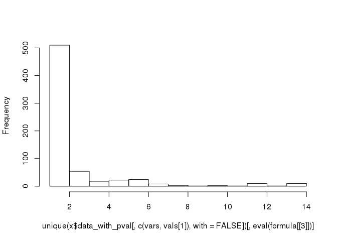

```r
selectTopHits = function(res, N){
    res$data_pval = unique(res$data_with_pval[,.(IDs_interactor_viral, IDs_domain_human, p.value, domain_type, domain_count, IDs_interactor_viral_degree)])
    pairs200pval = res$data_pval[order(p.value, decreasing = F)[1:N], max(p.value)]

    restop100 = res
    restop100$data_with_pval = restop100$data_with_pval[p.value <= pairs200pval, ]
    restop100$data_with_pval[, N_viral_per_human_w_domain := length(unique(IDs_interactor_viral)), by = .(IDs_interactor_human, IDs_domain_human)]
    return(restop100)
}
restop100 = selectTopHits(res_count, N = 250)
plot(restop100, IDs_interactor_human ~ N_viral_per_human_w_domain)
```

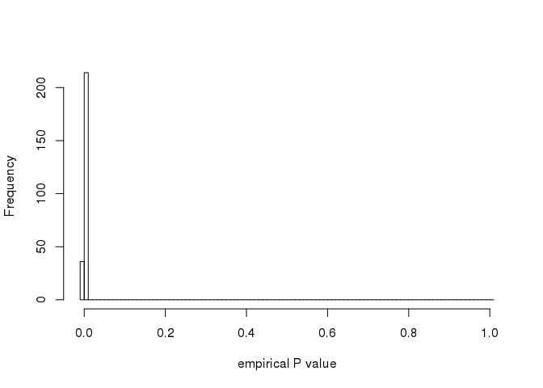

```r
plot(restop100)
```

### what are those domains? are they known ELM-interacting domains? which proteins they are in? which viral taxons they interact with?

```r
restop100$data_with_pval[N_viral_per_human_w_domain >= 10, unique(IDs_domain_human)]
```

```
## [1] "IPR007125" "IPR009072" "IPR032454" "IPR000504"
```

```r
restop100$data_with_pval[N_viral_per_human_w_domain >= 10, unique(IDs_domain_human)] %in% domains_known_mapped
```

```
## [1] FALSE FALSE FALSE  TRUE
```

```r
restop100$data_with_pval[N_viral_per_human_w_domain >= 10 & IDs_domain_human == "IPR000504", unique(IDs_interactor_human)]
```

```
## [1] "P09651" "P22626" "Q99729"
```

```r
restop100$data_with_pval[N_viral_per_human_w_domain >= 10 & IDs_domain_human == "IPR000504", unique(Taxid_interactor_viral)]
```

```
##  [1]  10377  28344 211044  10254 380964  88776 130763 128952 680716  10376
## [11]  11097
```

```r
DT::datatable(restop100$data_with_pval[N_viral_per_human_w_domain >= 10,])
```

|  | IDs_interactor_viral | IDs_domain_human | observed_statistic | YmissingZ_perX | higher_counts | not_missing | p.value | IDs_interactor_human | all_IDs_domain | domain_type | N_prot_w_interactors | domain_count | domain_frequency | Taxid_interactor_human | Taxid_interactor_viral | IDs_interactor_viral_degree | IDs_interactor_human_degree | IDs_domain_human_per_IDs_interactor_viral | IDs_interactor_viral_per_IDs_domain_human | domain_count_per_IDs_interactor_viral | domain_frequency_per_IDs_interactor_viral | fold_enrichment | N_viral_per_human_w_domain |
| --- | --- | --- | --- | --- | --- | --- | --- | --- | --- | --- | --- | --- | --- | --- | --- | --- | --- | --- | --- | --- | --- | --- | --- |
| 1 | Q9WMX2 | IPR007125 | 10 | 6 | 51780 | 669219120 | 7.73737606301506e-05 | P04908 | PF00125 | Domain | 15940 | 48 | 0.00301129234629862 | 9606 | 333284 | 61 | 14 | 99 | 22 | 10 | 0.163934426229508 | 54.4398907103825 | 14 |
| 2 | P03495 | IPR007125 | 19 | 6 | 0 | 1253572462 | 0 | P04908 | PF00125 | Domain | 15940 | 48 | 0.00301129234629862 | 9606 | 381517 | 60 | 14 | 85 | 22 | 19 | 0.316666666666667 | 105.159722222222 | 14 |
| 3 | Q997F2 | IPR007125 | 10 | 3 | 480 | 400943360 | 1.19717657875666e-06 | P04908 | PF00125 | Domain | 15940 | 48 | 0.00301129234629862 | 9606 | 121791 | 34 | 14 | 43 | 22 | 10 | 0.294117647058824 | 97.671568627451 | 14 |
| 4 | Q0HD54 | IPR007125 | 10 | 13 | 131730 | 752213540 | 0.000175123143888104 | P04908 | PF00125 | Domain | 15940 | 48 | 0.00301129234629862 | 9606 | 383543 | 70 | 14 | 73 | 22 | 10 | 0.142857142857143 | 47.4404761904762 | 14 |
| 5 | Q84940 | IPR007125 | 10 | 2 | 0 | 235533530 | 0 | P04908 | PF00125 | Domain | 15940 | 48 | 0.00301129234629862 | 9606 | 10915 | 19 | 14 | 19 | 22 | 10 | 0.526315789473684 | 174.780701754386 | 14 |
| 6 | P23057 | IPR007125 | 10 | 0 | 0 | 152808040 | 0 | P04908 | PF00125 | Domain | 15940 | 48 | 0.00301129234629862 | 9606 | 11214 | 12 | 14 | 9 | 22 | 10 | 0.833333333333333 | 276.736111111111 | 14 |
| 7 | Q05127 | IPR007125 | 25 | 9 | 0 | 1649643550 | 0 | P04908 | PF00125 | Domain | 15940 | 48 | 0.00301129234629862 | 9606 | 128952 | 60 | 14 | 68 | 22 | 25 | 0.416666666666667 | 138.368055555556 | 14 |
| 8 | Q9WPI5 | IPR007125 | 10 | 5 | 52120 | 669318510 | 7.78702504432456e-05 | P04908 | PF00125 | Domain | 15940 | 48 | 0.00301129234629862 | 9606 | 380964 | 61 | 14 | 98 | 22 | 10 | 0.163934426229508 | 54.4398907103825 | 14 |
| 9 | O56264 | IPR007125 | 24 | 3 | 24 | 2582410464 | 9.29364263914321e-09 | P04908 | PF00125 | Domain | 15940 | 48 | 0.00301129234629862 | 9606 | 130763 | 108 | 14 | 147 | 22 | 24 | 0.222222222222222 | 73.7962962962963 | 14 |
| 10 | P04487 | IPR007125 | 28 | 20 | 0 | 3809535128 | 0 | P04908 | PF00125 | Domain | 15940 | 48 | 0.00301129234629862 | 9606 | 10299 | 145 | 14 | 176 | 22 | 28 | 0.193103448275862 | 64.1264367816092 | 14 |

[output cut: 445 more lines]

## R session information

```r
filename = paste0("./processed_data_files/what_we_find_VS_ELM_clust",gsub("-","",Sys.Date()),".RData")
filename = paste0("./processed_data_files/what_we_find_VS_ELM_clust",gsub("-","","2017-10-19"),".RData")
save(list = ls(), file=filename)
#R.utils::gzip(filename = "./processed_data_files/what_we_find_VS_ELM_clust11092017.RData",
#              destname = "./processed_data_files/what_we_find_VS_ELM_clust11092017.RData.gz",
#              remove = T, overwrite = T)
Sys.Date()
```

```
## [1] "2017-10-25"
```